# Mixed models - socioeconomic predictors of forest cover

Matt Nuttall

23/06/20

This document is a summary of the ongoing analysis into predictors of forest cover/loss at the commune level across Cambodia.

Currently the response variable is raw count of forest pixels, and there are 9 predictor variable sets with varying numbers of predictors in each set. All predictor variables have been scaled and centered prior to analysis. A GLMM framework has been used, with a Poisson distribution and the following random effects structure:

**(year|Province/Commune)**

The logged area (KM) of each commune has been used as an offset term in each model.

The variable sets are as follows:

- POPULATION DEMOGRAPHICS - population density, total population, proportion of commune that are indigenous
- EDUCATION - proportion of males aged 6-24 in school
- EMPLOYMENT - proportion of people employed in the Primary sector, proportion of people emplyed in the Secondary sector
- ECONOMIC SECURITY - proportion of population with less than 1ha of farming land, proportion of families with pigs
- ACCESS TO SERVICES - median distance to nearest school (of all the villages within the commune), median distance to the Commune Office (of all the villages within the commune), proportion of families with access to waste collection services
- SOCIAL JUSTICE - total number of land conflict cases, number of criminal cases per capita
- MIGRATION - total number of in-migrants, total number of out-migrants
- ENVIRONMENTAL (CONTROL) - mean elevation, habitat
- HUMAN (CONTROL) - distance to international border, distance to Provincial Capital, PA presence, PA category, economic land concession presence

## summary of results

Unfortunately, none of the socioeconomic predictors appear to have any predictive power! The only exception is population density. The “control” variables (Environmental, Human, see above) however, do have some predictive power. Below I will show the results of the initial models for each set.

My general conclusion thus far however is that with this response, I still don’t think I am asking the question I want to. I think the models below are telling us which variables can predict forest cover (i.e. where is the forest? Which communes have lots of forest and which ones have little forest?). I don’t think the below models can really tell me anything about forest *loss*, or which variables are able to predict forest cover loss/change. I feel like I need to go further and look at forest cover change as a response (e.g. rate of change / difference in forest pixels). That’s not to say that what I have done so far is not useful - I think in combination with further analysis we can build up a wider picture of forest cover and forest cover dynamics. For example, the overall analysis and our results could be made up of the following:

- Which variables predict where forest cover is greatest / lowest across the country? (this is what I have done. Although at the moment the question is really "…where forest cover is greatest/lowest given there is SOME forest. This is because I removed all communes with 0 forest cover right at the start, as at that stage I was planning on useing rate of change as a response and so communes with no forest were false 0’s)
- Which variables predict where forest is likely to be lost? (Presumably I could use binomial logistic model here: forest lost/not lost)
- Then subset the communes to only those that have lost some forest, and then model rate of change / magnitude of change. (Initially this is what I was going to do, either manually i.e. two steps, or via a hurdle model)

I keep having to remind myself of what the purpose of this analysis is. The purpose is to use the resulting model(s) to predict where in the country forest is likely to be lost under various potential scenarios. I want to be able to highlight communes where forest cover is likely to be lost if, say, population density in rural areas goes up, or if the number of land conflicts in communes with land concessions spike. The aim WAS then to use these predictions to assess the robustness of the national wildlife corridor network to future changes. But in theory I could do a number of things, e.g. identifiy which PAs are most vulnerable to certain future scenarios etc. The main point being though, is that I don’t think I can use the below models to do that.

Unless I am mis-understanding the usefulness of the models below. Please feel free to correct me if you think I am interpreting this incorrectly. The only way I can think to use these models to do what I want, is using the below approach:

- Ignore the “global” model (i.e. the model with RE’s set to means)
- Pull out the individual communes of interest, e.g. the ones within the wildlife corridor, or the ones in/around the PAs
- run the commune-specific models (i.e. with RE’s specific to that commune) with varying ranges of the predictors, e.g. increasing population density.

That approach above though, doesn’t feel right to me. This is because at the moment, if I adjusted model parameters to simulate a particular commune increasing, say, its population density, I don’t feel like the result would reflect forest cover dynamics in that commune. I feel like it would be more llike saying - “if this commune happened to have a higher population density, it would probably have this amount of forest”, which I think is subtley but importantly different from saying - “if population density increased in this communes, this commune would likely lose xx amount of forest”.

The other obvious problem with the above approach is that I don’t really have any socioeconomic predictors (apart from population density) to play with as they’re all a bit shit! The other predictor variables that have some predictive power are mostly unchangeable i.e. elevation, distance to Provincial capital etc.

So I am currently unsure how best to proceed, and I would very much appreciate some guidance! Below I will summarise the models, the diagnostics, and the predictions.

# Model results

## Population demographics

Full population demographics model below. `tot_pop` = total population, `pop_den` = population density, `prop_ind` = proporition indigneous.

```r
popdem.m1 <- glmer(ForPix ~ tot_pop + pop_den + prop_ind + offset(log(areaKM)) + (year|Province/Provcomm),
                   data=dat1, family="poisson")

summary(popdem.m1)
```

```
## Generalized linear mixed model fit by maximum likelihood (Laplace
##   Approximation) [glmerMod]
##  Family: poisson  ( log )
## Formula: ForPix ~ tot_pop + pop_den + prop_ind + offset(log(areaKM)) +
##     (year | Province/Provcomm)
##    Data: dat1
##
##      AIC      BIC   logLik deviance df.resid
##  36566.2  36629.7 -18273.1  36546.2     4231
##
## Scaled residuals:
##     Min      1Q  Median      3Q     Max
## -6.1086 -0.0875 -0.0089  0.0353  9.7876
##
## Random effects:
##  Groups            Name        Variance  Std.Dev. Corr
##  Provcomm:Province (Intercept) 1.5079926 1.22800
##                    year        0.0046008 0.06783  0.21
##  Province          (Intercept) 1.6584683 1.28782
##                    year        0.0006834 0.02614  -0.30
## Number of obs: 4241, groups:  Provcomm:Province, 737; Province, 24
##
## Fixed effects:
##               Estimate Std. Error z value Pr(>|z|)
## (Intercept) -0.1922840  0.3229265  -0.595    0.552
## tot_pop      0.0059904  0.0048601   1.233    0.218
## pop_den     -0.1713321  0.0361147  -4.744 2.09e-06 ***
## prop_ind    -0.0001633  0.0014870  -0.110    0.913
## ---
## Signif. codes:  0 '***' 0.001 '**' 0.01 '*' 0.05 '.' 0.1 ' ' 1
##
## Correlation of Fixed Effects:
##          (Intr) tot_pp pop_dn
## tot_pop   0.011
## pop_den  -0.044 -0.442
## prop_ind  0.004 -0.003  0.013
```

Variance for Province and commune are similar. Variance for year at both levels is small, but an order of magnitude smaller for the Province level. Approximate p values are significant for pop_den only. tot_pop is positive effect, pop_den and prop_ind are negative. No real correlation between fixed effects.Note: I did run the model without offset and the variance for Province and Provcomm:Province were double what they are now that offset is included.

Plot the random effects. First plot is Commune and year, second plot is Province and year

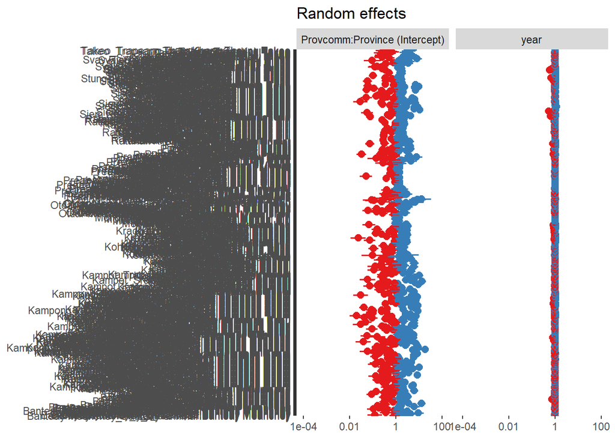

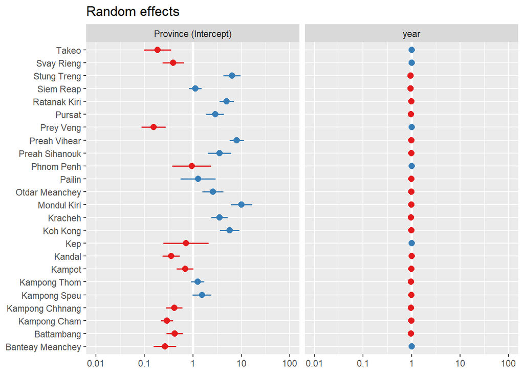

The model summary and likelihood ratio tests suggested proportion indigneous was contributing little, and so that variable was dropped. There was evidence of an interaction between population density and total population, and likelihood ratio tests suggested the model with both terms in was better than the model with only population density, but these two variables are intrinsically linked, and so I dropped total population, as it had the weaker effect. As a note on LRT’s - my protocol was to begin with simple ‘anova(test=“Chisq”)’ and if there was a variable/model that had a p-value that was hovering around 0.05, then I would progress to another test (e.g. profiled CI’s, bootstrapping, but this was never really necessary).

Therefore the final population demographics model is:

```r
popdem.m6 <- glmer(ForPix ~ pop_den + offset(log(areaKM)) + (year|Province/Provcomm),
                   data = dat1, family = "poisson")

summary(popdem.m6)
```

```
## Generalized linear mixed model fit by maximum likelihood (Laplace
##   Approximation) [glmerMod]
##  Family: poisson  ( log )
## Formula: ForPix ~ pop_den + offset(log(areaKM)) + (year | Province/Provcomm)
##    Data: dat1
##
##      AIC      BIC   logLik deviance df.resid
##  36563.7  36614.5 -18273.8  36547.7     4233
##
## Scaled residuals:
##     Min      1Q  Median      3Q     Max
## -6.1084 -0.0883 -0.0101  0.0375  9.7922
##
## Random effects:
##  Groups            Name        Variance  Std.Dev. Corr
##  Provcomm:Province (Intercept) 1.5132917 1.23016
##                    year        0.0045951 0.06779  0.21
##  Province          (Intercept) 1.6742072 1.29391
##                    year        0.0006786 0.02605  -0.30
## Number of obs: 4241, groups:  Provcomm:Province, 737; Province, 24
##
## Fixed effects:
##             Estimate Std. Error z value Pr(>|z|)
## (Intercept) -0.19661    0.32427  -0.606    0.544
## pop_den     -0.15155    0.03236  -4.683 2.83e-06 ***
## ---
## Signif. codes:  0 '***' 0.001 '**' 0.01 '*' 0.05 '.' 0.1 ' ' 1
##
## Correlation of Fixed Effects:
##         (Intr)
## pop_den -0.042
```

### Diagnostics

Plot of predicted values vs observed values

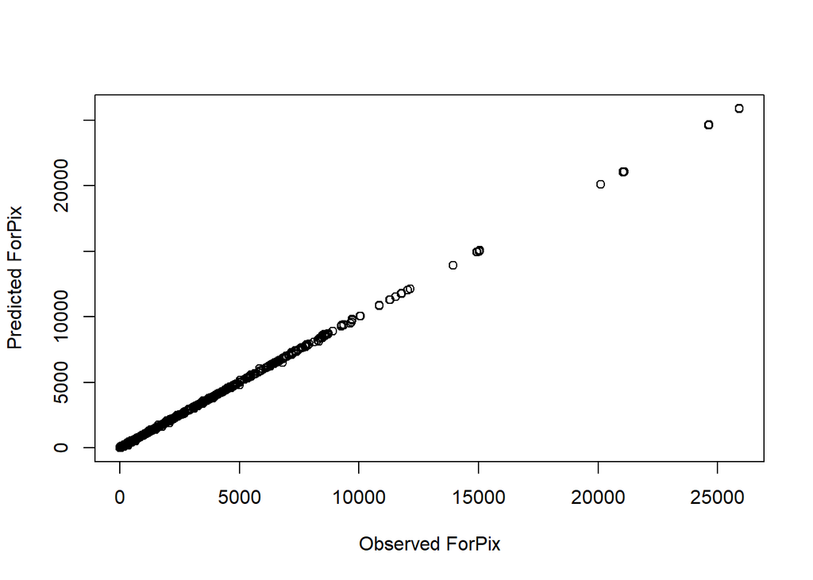

This plot looks good.

Below is a plot of residuals vs fitted values

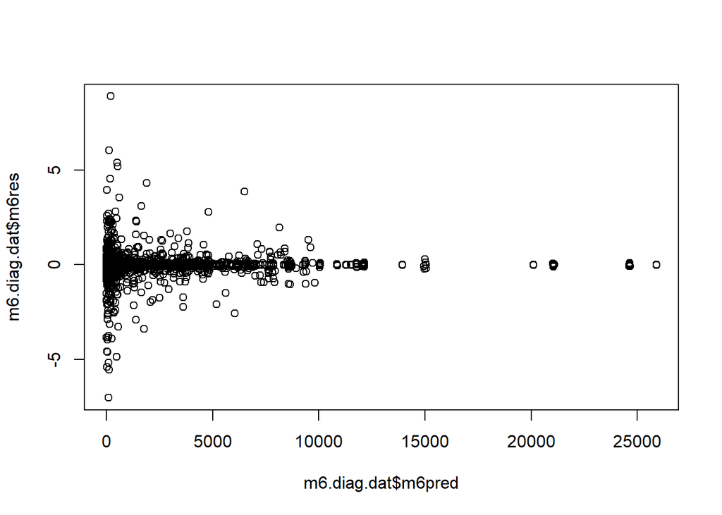

Quite bad heterogeneity here. Jeroen suggested this could be due to missing predictors, however this was also the case for previous models that had the other 2 predictors. At low predicted values, error is greater. As Jeroren said - given the structure in the data, this is almost inevitable given the extent of variation across communes. As we will see, this is an issues with all of the models.

Exploration of the residuals over the predictors, and between provinces and communes:

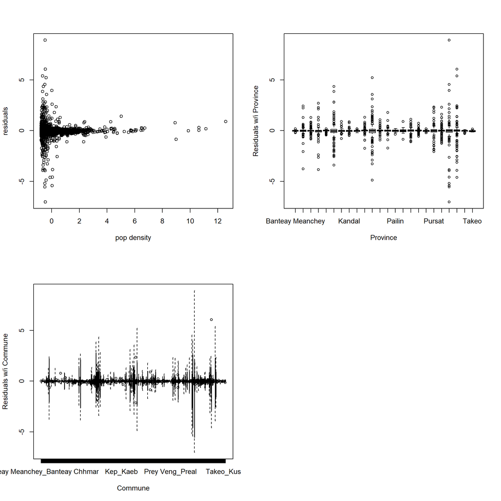

A lot of the heterogeneity is driven by relatively few communes/provinces. I investigated further. If you look at the map (in GIS), the provinces with the smallest residuals are the smaller provinces in the south surrounding the capital Phnom Penh. These are provinces that generally have very little forest. But they are not the only provinces with no forest cover, so I am not sure that is the (only) reason. I think I need to look at the communes within the provinces.

Here I plot forest pixels for each commune, separated by the communes with high residuals in the model (“problem”), and the rest (“other”):

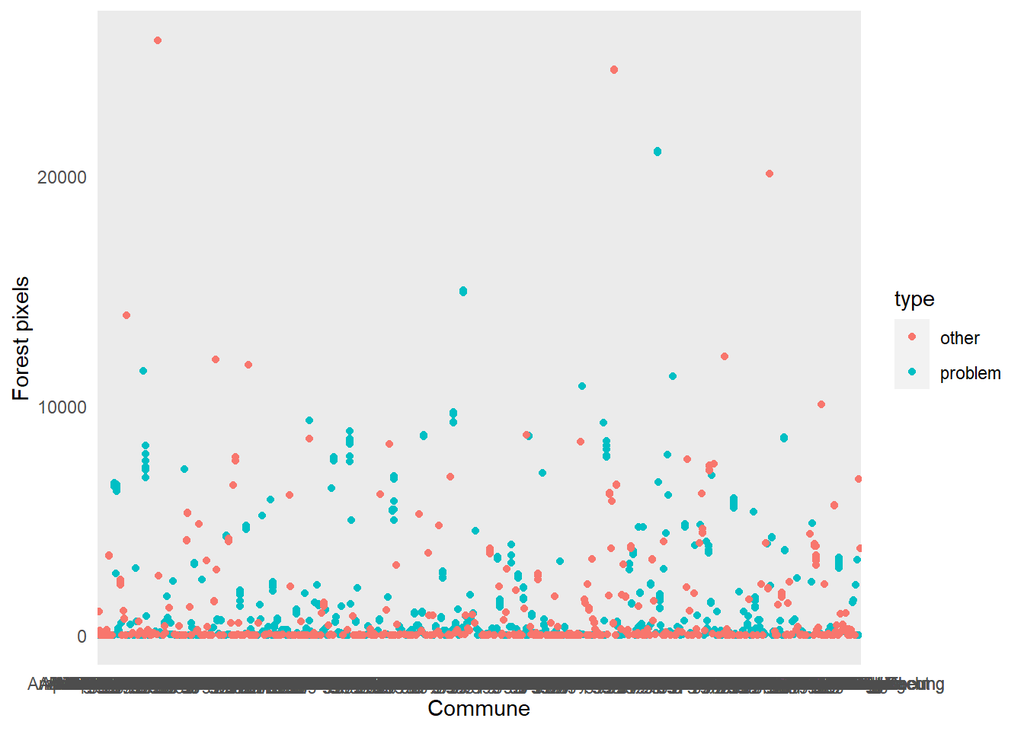

I would say that the provinces that are causing the issues tend to have higher ForPix than the others. It also look potentially like the provinces causing issues are almost always losing forest cover over time (lots of vertical lines of dots).

Plot of population density (the predictor) against forest pixels, split by the problem communes again. I have zoomed in on both axes so we can see what is going on a bit better:

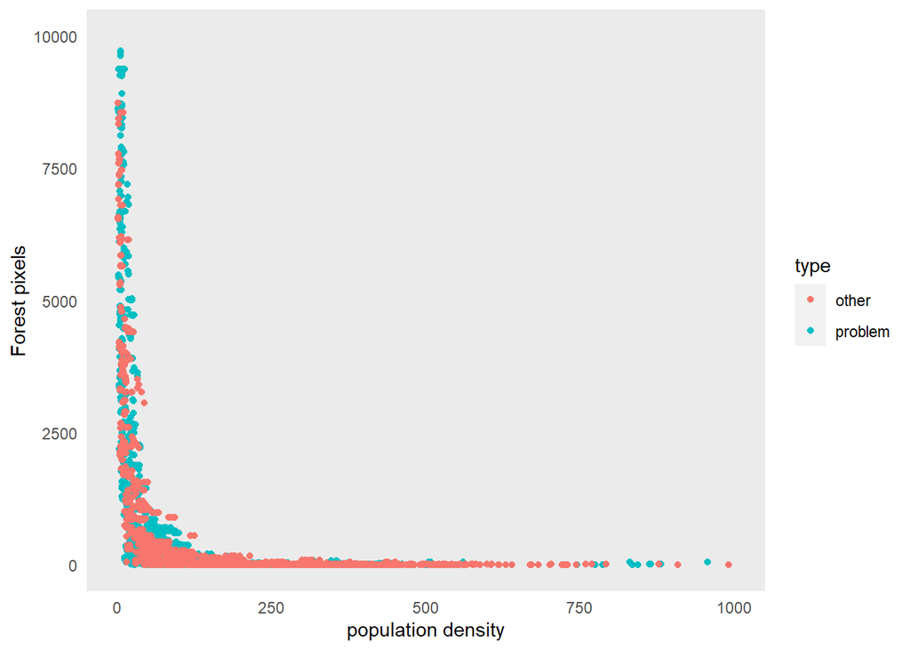

This plot makes it also look like the problem provinces tend to have communes with higher ForPix (although this is clearly not true for all communes). There is a chunk of blue with no pink where pop_den has increased to about 100 but ForPix has not decreased (whereas almost all the pink dots are lower, i.e. in the other provinces/communes at that population density forest cover is lower).

The plot below shows the forest pixels by province (rather than commune), split by the problem provinces.

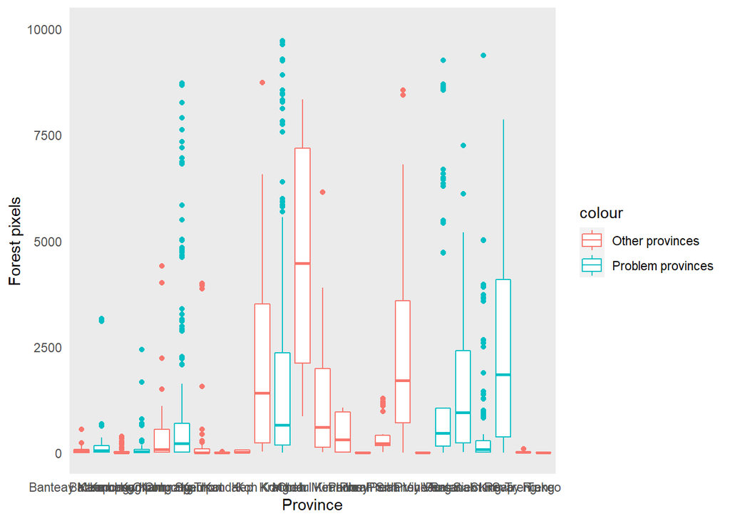

This plot suggests that the problem provinces don’t necessarily have more (mean) forest cover, but they do tend to have more outliers (individual communes) that are very high forest cover.

The plot below shows the population density by province, split by the problem provinces.

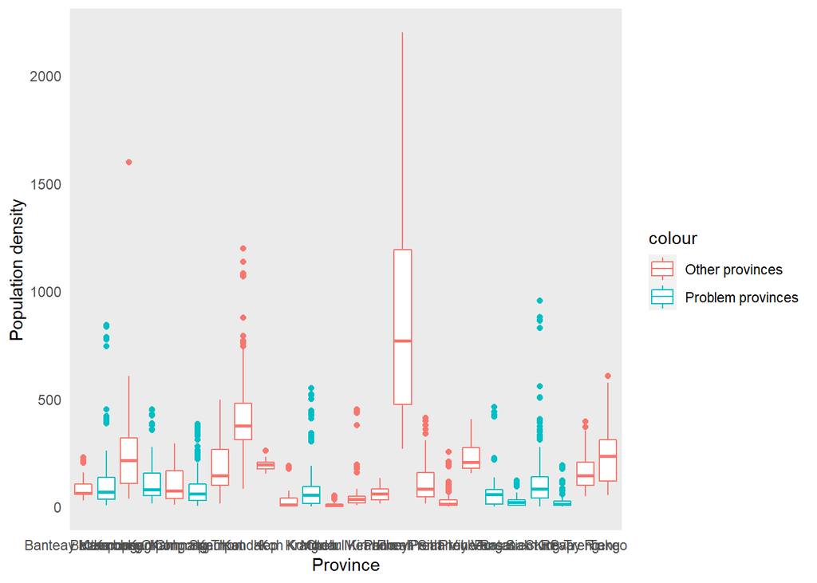

This plot suggests that overall, the problem provinces tend to have lower median pop_den value compared to the other provinces, but they again tend to have more outliers. This is what I would expect - the communes with lower population density will also likely be the communes with higher forest cover (as we saw in the above plots).

The plot below shows the same as above but by communes, rather than province

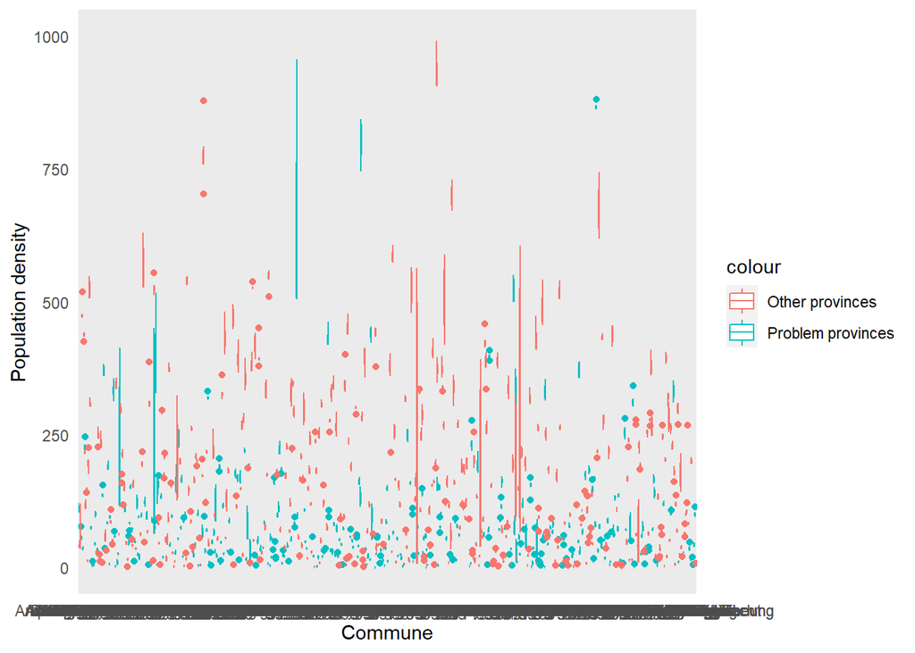

Although slightly difficult to interpret, again this looks like there are more communes with higher pop_den values in the non-problematic provinces. And in the problem communes with higher population density values, they also tend to have much more variation in population density (i.e. the pop_den changes a lot over time)

The plot below shows the problem communes and their forest pixels:

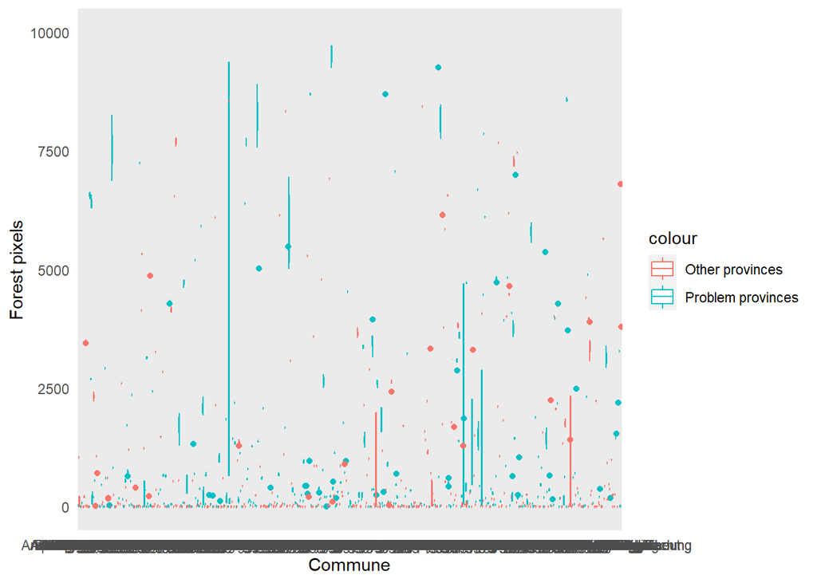

Again, difficult to see a huge amount, however I would say that it looks like the problem provinces in general have more variation in ForPix, both within communes and between communes.

If you look at the plot of the main effect below, the line is pretty flat, even at low pop_den and ForPix values. This is where the model is not predicitng well for communes with low population density but higher forest cover. This is because there is so much variation in the communes - i.e. there are so many that have low pop_den but low ForPix, which is dragging the model down. So the communes with large residuals are going to be the commune with low pop_den values and higher ForPix values I think. I do not think there is much I can do about this? Would including year as a fixed effect perhaps help account for the variation within communes across years?

### Predict main (global) effects

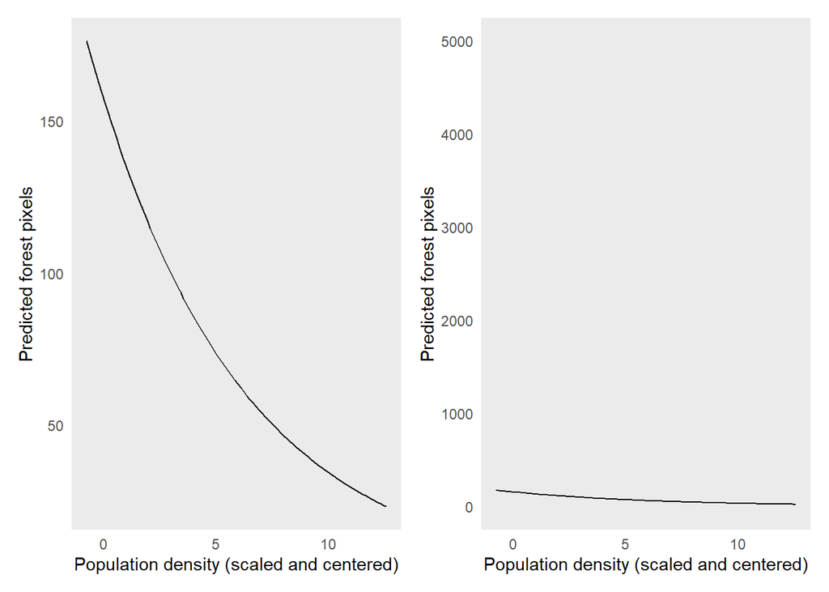

We can see in the plots above that the effect is there (left plot), but it is small when you look at it with a more realistic y-axis, i.e. with forest pixel values more like those that are actually seen (right plot)

### Predict for specific communes

Here I want to plot grids of different communes with the overall predicted effect, plus the commune-specific effect. I want to do this for communes with commune-level intercepts close to the mean, and communes with commune-level intercepts at the extremes. I will also do this for a random sample of communes.

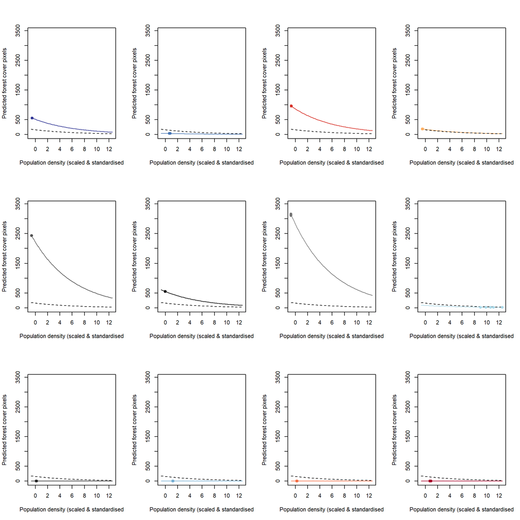

In the above plots, the top row are communes with intercepts closest to the mean, the middle row are communes with intercepts furthest above the mean, and the bottom row are communes with intercepts furthest below the mean. The coloured solid lines are the commune-specific predictions, i.e. those made using all RE’s specific to that commune. The dashed black line is the global model (i.e. for an “average” commune). The points are the actual pop_den ~ ForPix values for that commune. The plots support the diagnostics in the section above - the global model does not predict well for communes with high forest cover - because the global model always predicts low forest cover, even for communes with low population density. Essentially there are too many communes with low forest cover, and so the global model is dragged down, meaning that the communes with high forest cover get poor predictions. This does suggest though that the global model predicts well at high population density values, as these communes tend to have low forest cover.

Now I will do the same but for 9 random selections of 9 communes.

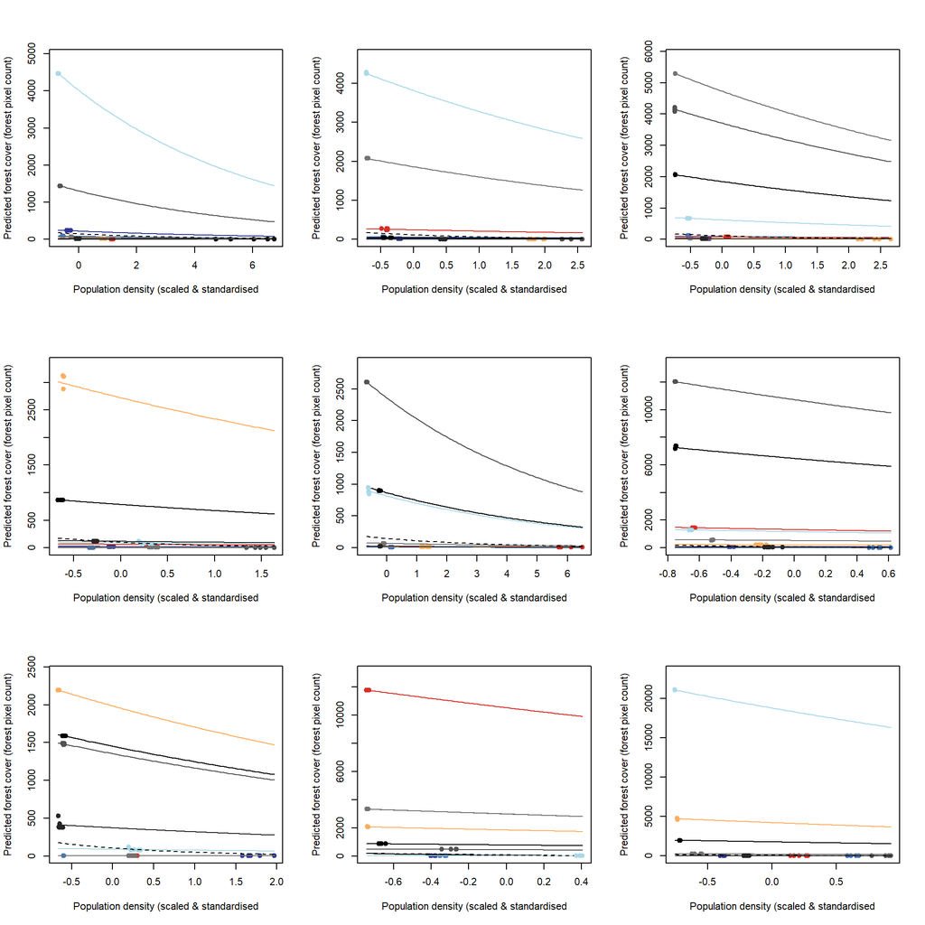

The above plots I think support the assessment that the global model predicts poorly for most communes, but I would expect this as there is so much variation between communes, it would be impossible to get a single model that predicted well. The above plots suggest that the commune-specific models predict better for communes where population density changes over time, but they predict poorly for communes when forest pixels change over time (i.e. forest is lost). Communes with more forest are, in general, more likely to lose forest (see plot below), which I think exacerbates the problem of the global model predicting poorly for communes with high forest cover i.e. it’s a double whammy of poor predictions due to high forest cover, and poor predictions due to forest loss.

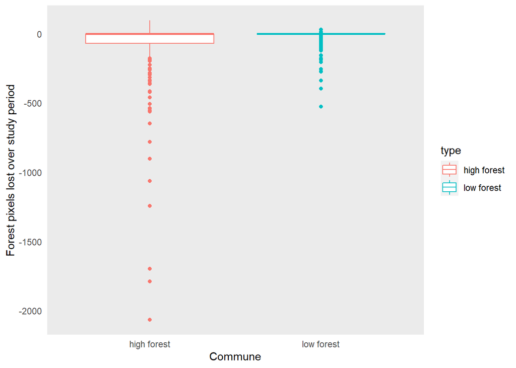

## Education

```r
edu.m1 <- glmer(ForPix ~ M6_24_sch + offset(log(areaKM)) + (year|Province/Provcomm), family="poisson", data=dat1)
summary(edu.m1)
```

```
## Generalized linear mixed model fit by maximum likelihood (Laplace
##   Approximation) [glmerMod]
##  Family: poisson  ( log )
## Formula: ForPix ~ M6_24_sch + offset(log(areaKM)) + (year | Province/Provcomm)
##    Data: dat1
##
##      AIC      BIC   logLik deviance df.resid
##  36585.6  36636.4 -18284.8  36569.6     4233
##
## Scaled residuals:
##     Min      1Q  Median      3Q     Max
## -6.1130 -0.0772 -0.0031  0.0244  9.7591
##
## Random effects:
##  Groups            Name        Variance  Std.Dev. Corr
##  Provcomm:Province (Intercept) 1.5755640 1.25521
##                    year        0.0045875 0.06773  0.20
##  Province          (Intercept) 1.8868714 1.37363
##                    year        0.0007466 0.02732  -0.32
## Number of obs: 4241, groups:  Provcomm:Province, 737; Province, 24
##
## Fixed effects:
##               Estimate Std. Error z value Pr(>|z|)
## (Intercept) -2.573e-01  3.523e-01  -0.730    0.465
## M6_24_sch    7.254e-05  8.573e-04   0.085    0.933
##
## Correlation of Fixed Effects:
##           (Intr)
## M6_24_sch 0.002
## convergence code: 0
## Model is nearly unidentifiable: very large eigenvalue
##  - Rescale variables?
```

The model output suggests there is nothing going on here. I can use ‘plot_model’ from the sjPlot package to quickly plot a prediction. It basically does exactly what I would do - create newdata with the variable of interest varying from the min to the max, and holding all others at their mean. You can specify whether you want it to plot conditional on the fixed effects only (i.e. “average” comune / global model), or on the random effects. The below is conditionl on fixed effects only.

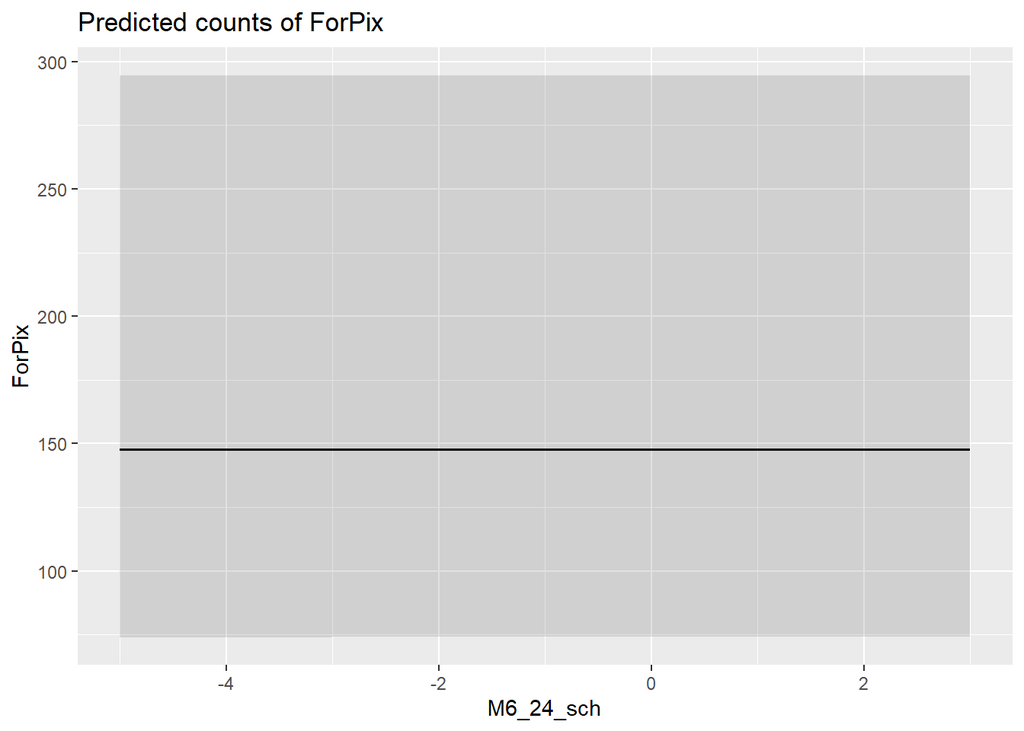

Flat as a pancake.

Below are some commune-specific predictions from another random selection of communes

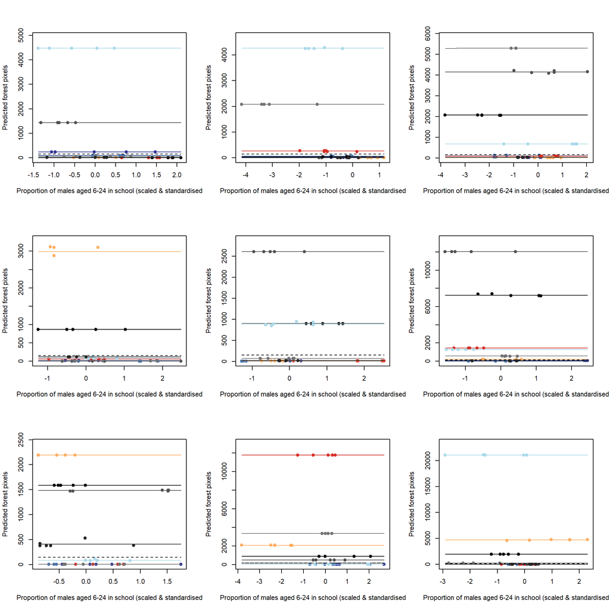

I think it is fair to say that there is no relationship between forest cover and males in school.

## Employment

There are two variables in this set - the proportion of the population engaged in the Primary Sector and the proportion engaged in the Secondary Sector. The primary sector includes sectors of the economy that extracts or harvests products from the earth such as raw materials and basic foods, and includes farming, fishing, mining etc. The secondary sector includes the production of finished goods from raw materials, and includes manufacturing, processing, and construction.

I have no *a priori* hypothesis about an interaction between these two variables, and so I have not tested one. It is also plausible that although these two are not correlated (-0.2), they may well be related as they are both proportions drawn from the same population, therefore including an interaction might be misleading.

The model:

```r
emp.m1 <- glmer(ForPix ~ propPrimSec + propSecSec + offset(log(areaKM)) + (year|Province/Provcomm),
                family="poisson", data=dat1)
```

```
## Warning in checkConv(attr(opt, "derivs"), opt$par, ctrl = control$checkConv, : Model is nearly unidentifiable: very large eigenvalue
##  - Rescale variables?
```

```r
summary(emp.m1)
```

```
## Generalized linear mixed model fit by maximum likelihood (Laplace
##   Approximation) [glmerMod]
##  Family: poisson  ( log )
## Formula: ForPix ~ propPrimSec + propSecSec + offset(log(areaKM)) + (year |
##     Province/Provcomm)
##    Data: dat1
##
##      AIC      BIC   logLik deviance df.resid
##  36587.1  36644.3 -18284.5  36569.1     4232
##
## Scaled residuals:
##     Min      1Q  Median      3Q     Max
## -6.1089 -0.0776 -0.0067  0.0271  9.7536
##
## Random effects:
##  Groups            Name        Variance  Std.Dev. Corr
##  Provcomm:Province (Intercept) 1.5753467 1.25513
##                    year        0.0045890 0.06774  0.20
##  Province          (Intercept) 1.8859595 1.37330
##                    year        0.0007379 0.02716  -0.32
## Number of obs: 4241, groups:  Provcomm:Province, 737; Province, 24
##
## Fixed effects:
##               Estimate Std. Error z value Pr(>|z|)
## (Intercept) -0.2558445  0.3512908  -0.728    0.466
## propPrimSec  0.0009114  0.0015006   0.607    0.544
## propSecSec  -0.0004766  0.0015063  -0.316    0.752
##
## Correlation of Fixed Effects:
##             (Intr) prpPrS
## propPrimSec  0.000
## propSecSec  -0.010  0.126
## convergence code: 0
## Model is nearly unidentifiable: very large eigenvalue
##  - Rescale variables?
```

Province and commune variance similar to other model sets. Year variance for commune is an order of magnitude larger than for province, but both very small. propPrimSec has positive effect, propSecSec has negative, but both very small and approximate p values > 0.5. The model produces a warning about large eigenvalues. The variables are already scaled so I guess this just suggests a poor model fit.

Quick plot of the effects

[figure not shown]

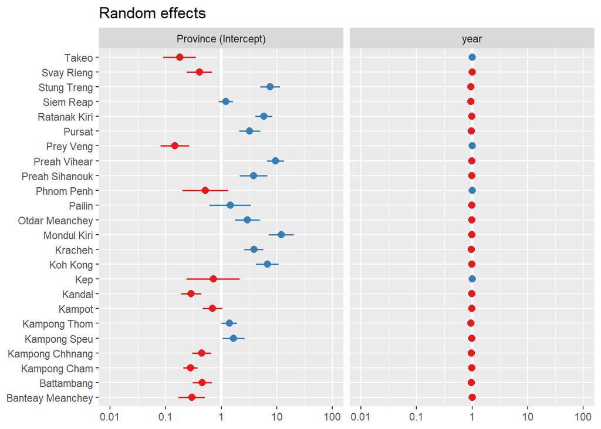

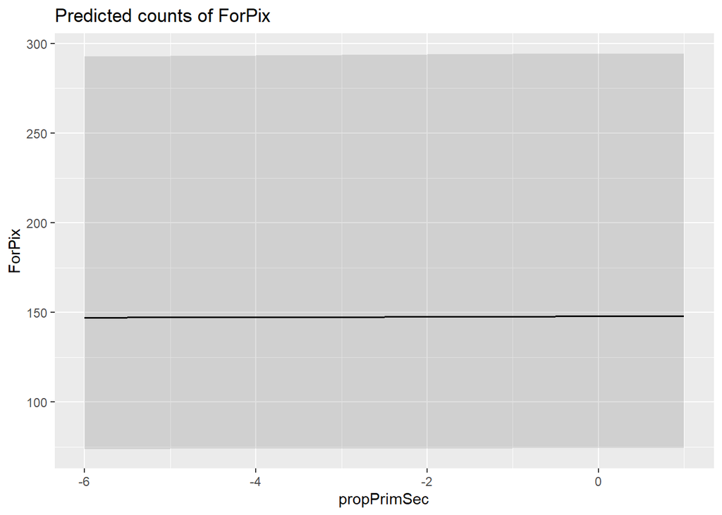

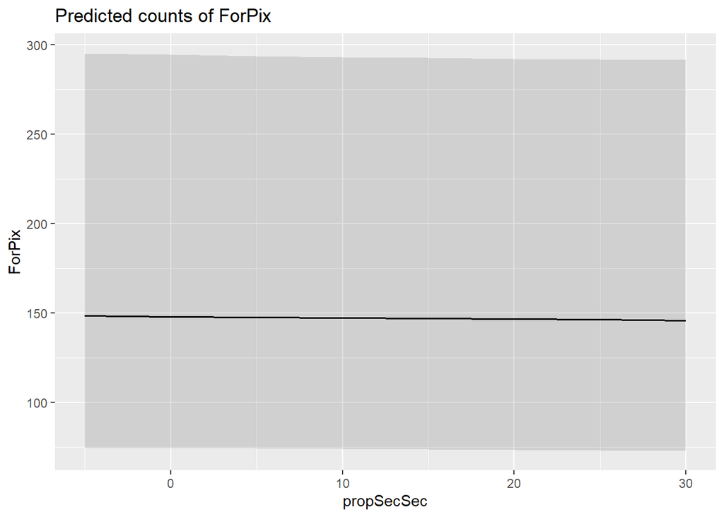

These two variables do not appear to be important. I will try and remove propSecSec

```r
emp.m2 <- glmer(ForPix ~ propPrimSec + offset(log(areaKM)) + (year|Province/Provcomm), family="poisson", data=dat1)

summary(emp.m2)
```

```
## Generalized linear mixed model fit by maximum likelihood (Laplace
##   Approximation) [glmerMod]
##  Family: poisson  ( log )
## Formula:
## ForPix ~ propPrimSec + offset(log(areaKM)) + (year | Province/Provcomm)
##    Data: dat1
##
##      AIC      BIC   logLik deviance df.resid
##  36585.2  36636.0 -18284.6  36569.2     4233
##
## Scaled residuals:
##     Min      1Q  Median      3Q     Max
## -6.1094 -0.0779 -0.0063  0.0268  9.7535
##
## Random effects:
##  Groups            Name        Variance Std.Dev. Corr
##  Provcomm:Province (Intercept) 1.575382 1.25514
##                    year        0.004587 0.06773  0.20
##  Province          (Intercept) 1.886568 1.37352
##                    year        0.000740 0.02720  -0.32
## Number of obs: 4241, groups:  Provcomm:Province, 737; Province, 24
##
## Fixed effects:
##               Estimate Std. Error z value Pr(>|z|)
## (Intercept) -0.2570165  0.3505984  -0.733    0.464
## propPrimSec  0.0009714  0.0014885   0.653    0.514
##
## Correlation of Fixed Effects:
##             (Intr)
## propPrimSec 0.002
```

Compare the two models:

```r
anova(emp.m1, emp.m2, test="Chisq")
```

```
## Data: dat1
## Models:
## emp.m2: ForPix ~ propPrimSec + offset(log(areaKM)) + (year | Province/Provcomm)
## emp.m1: ForPix ~ propPrimSec + propSecSec + offset(log(areaKM)) + (year |
## emp.m1:     Province/Provcomm)
##        npar   AIC   BIC logLik deviance  Chisq Df Pr(>Chisq)
## emp.m2    8 36585 36636 -18285    36569
## emp.m1    9 36587 36644 -18285    36569 0.1001  1     0.7517
```

The simpler model is better, but is still pretty uninteresting

## Economic Security

In this set there are two variables - the proportion of families who have less than 1 hectare of agricultural land, and the proportion of families who keep pigs. Both of these things are fairly good proxies for a family’s economic security, especially the farming land variable.

```r
econ.m1 <- glmer(ForPix ~ Les1_R_Land + pig_fam + offset(log(areaKM)) + (year|Province/Provcomm),
                 family="poisson", data=dat1)
summary(econ.m1)
```

```
## Generalized linear mixed model fit by maximum likelihood (Laplace
##   Approximation) [glmerMod]
##  Family: poisson  ( log )
## Formula: ForPix ~ Les1_R_Land + pig_fam + offset(log(areaKM)) + (year |
##     Province/Provcomm)
##    Data: dat1
##
##      AIC      BIC   logLik deviance df.resid
##  36586.5  36643.7 -18284.3  36568.5     4232
##
## Scaled residuals:
##     Min      1Q  Median      3Q     Max
## -6.1123 -0.0790 -0.0077  0.0281  9.7589
##
## Random effects:
##  Groups            Name        Variance  Std.Dev. Corr
##  Provcomm:Province (Intercept) 1.5755114 1.25519
##                    year        0.0045894 0.06775  0.20
##  Province          (Intercept) 1.8858094 1.37325
##                    year        0.0007319 0.02705  -0.32
## Number of obs: 4241, groups:  Provcomm:Province, 737; Province, 24
##
## Fixed effects:
##               Estimate Std. Error z value Pr(>|z|)
## (Intercept) -2.560e-01  3.502e-01  -0.731    0.465
## Les1_R_Land -8.599e-05  1.063e-03  -0.081    0.936
## pig_fam      1.396e-03  1.339e-03   1.043    0.297
##
## Correlation of Fixed Effects:
##             (Intr) L1_R_L
## Les1_R_Land -0.002
## pig_fam      0.004 -0.033
## convergence code: 0
## Model is nearly unidentifiable: very large eigenvalue
##  - Rescale variables?
```

Very small effects with large approximate p values. Random effects similar to previous models. Les1_R_Land has a tiny negative effect, pig_fam has a small positive effect.

Quick plot of the main effects:

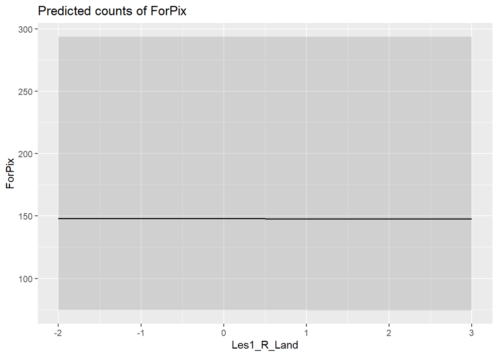

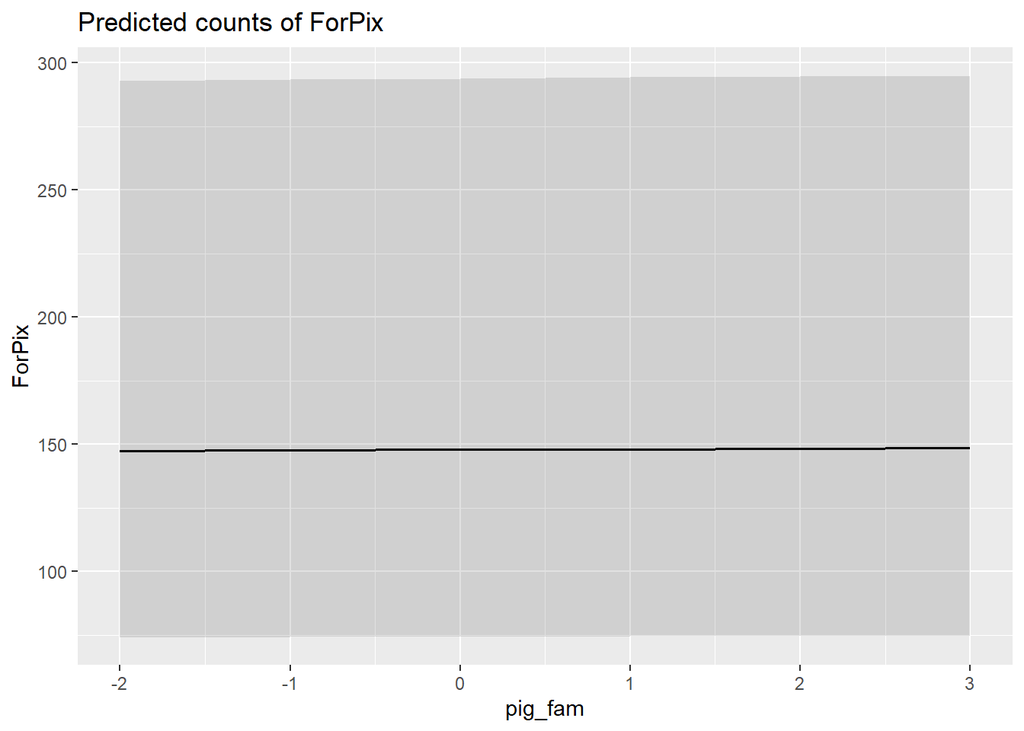

Again, these variables do not look like they can provide much. I did run model selection, and the simpler models (i.e. with just one of the vars) were better than model 1 with both variables, but the effects were similarly tiny.

## Access to Services

This model set has three variables - median distance to the nearest school, median distance to the Commune office, and the proportion of families with access to waste collection.

```r
acc.m1 <- glmer(ForPix ~ dist_sch + garbage + KM_Comm + offset(log(areaKM)) +
                  (year|Province/Provcomm),family="poisson", data=dat1)
```

```
## Warning in checkConv(attr(opt, "derivs"), opt$par, ctrl = control$checkConv, : Model is nearly unidentifiable: very large eigenvalue
##  - Rescale variables?
```

```r
summary(acc.m1)
```

```
## Generalized linear mixed model fit by maximum likelihood (Laplace
##   Approximation) [glmerMod]
##  Family: poisson  ( log )
## Formula: ForPix ~ dist_sch + garbage + KM_Comm + offset(log(areaKM)) +
##     (year | Province/Provcomm)
##    Data: dat1
##
##      AIC      BIC   logLik deviance df.resid
##  36589.3  36652.8 -18284.7  36569.3     4231
##
## Scaled residuals:
##     Min      1Q  Median      3Q     Max
## -6.1129 -0.0776 -0.0045  0.0257  9.7576
##
## Random effects:
##  Groups            Name        Variance Std.Dev. Corr
##  Provcomm:Province (Intercept) 1.575632 1.25524
##                    year        0.004584 0.06770  0.20
##  Province          (Intercept) 1.887185 1.37375
##                    year        0.000747 0.02733  -0.32
## Number of obs: 4241, groups:  Provcomm:Province, 737; Province, 24
##
## Fixed effects:
##               Estimate Std. Error z value Pr(>|z|)
## (Intercept) -2.575e-01  3.524e-01  -0.731    0.465
## dist_sch    -2.618e-04  7.166e-04  -0.365    0.715
## garbage     -8.353e-04  1.965e-03  -0.425    0.671
## KM_Comm      2.144e-05  9.065e-04   0.024    0.981
##
## Correlation of Fixed Effects:
##          (Intr) dst_sc garbag
## dist_sch  0.009
## garbage  -0.007  0.025
## KM_Comm   0.000  0.005 -0.003
## convergence code: 0
## Model is nearly unidentifiable: very large eigenvalue
##  - Rescale variables?
```

Also produces warning about large eigenvalues. All three variables have tiny effects with large approximate p values.

Quick plots of the main effects

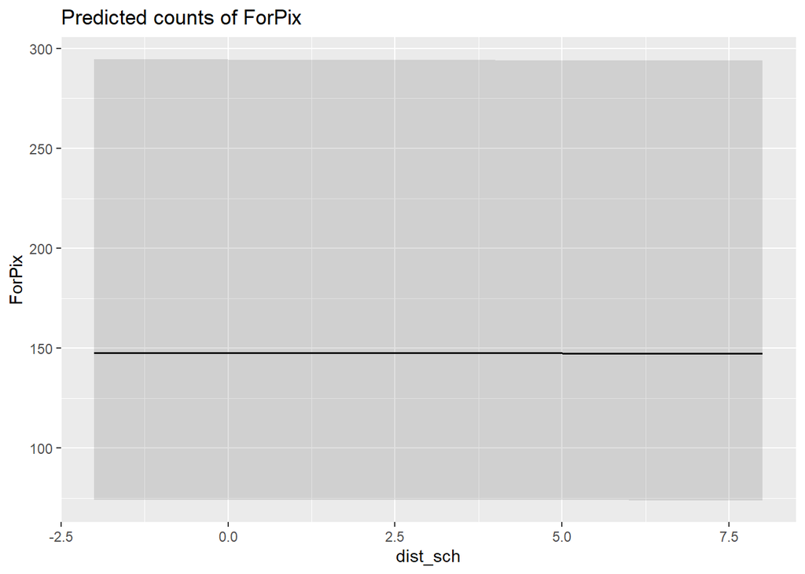

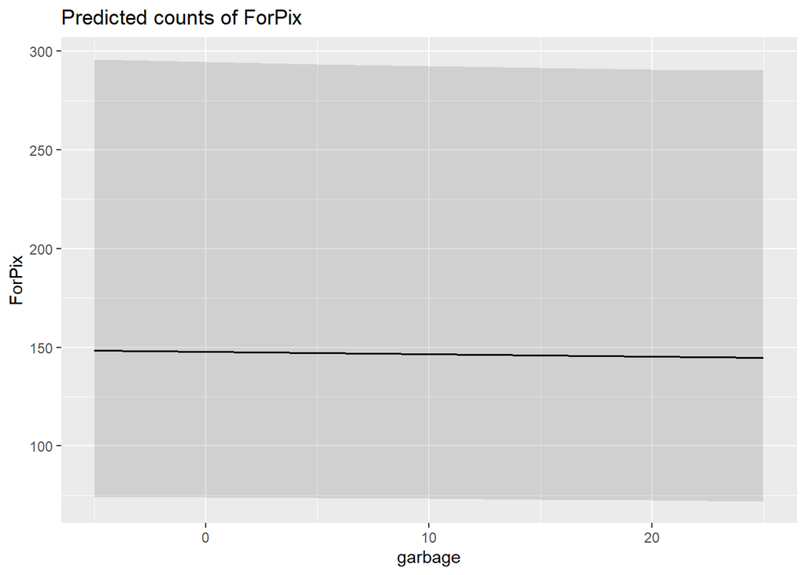

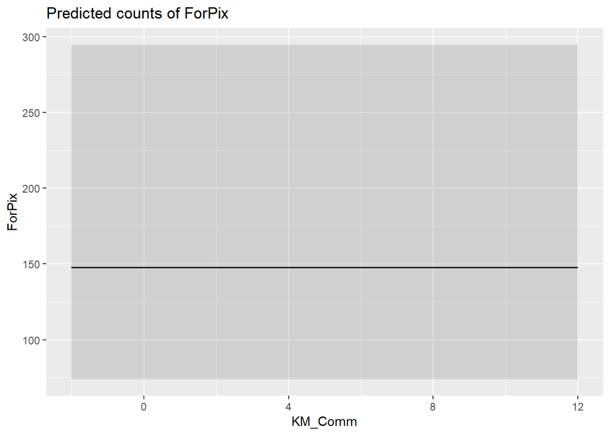

These variables do not appear to be useful. I completed model selection using a combination of LRT’s and AICc comparison, and all of the models with only an individual predictor were better than any model with more than one predictor. The top three models were therefore models with each of the single predictors, and there was virtually no difference between them (dAICc < 0.1). But they were equally as useless as the acc.m1 i.e. tiny effects, large approximate p values, flat main effect.

## Social Justice

This set includes two predictor variables - the raw number of land conflict cases, and the per capita number of criminal cases. I had no *a priori* hypothesis about an interaction between these two variables, and so I did not test one.

```r
jus.m1 <- glmer(ForPix ~ crim_case + land_confl + offset(log(areaKM)) + (year|Province/Provcomm),
                          family="poisson", data=dat1)
summary(jus.m1)
```

```
## Generalized linear mixed model fit by maximum likelihood (Laplace
##   Approximation) [glmerMod]
##  Family: poisson  ( log )
## Formula: ForPix ~ crim_case + land_confl + offset(log(areaKM)) + (year |
##     Province/Provcomm)
##    Data: dat1
##
##      AIC      BIC   logLik deviance df.resid
##  36587.4  36644.6 -18284.7  36569.4     4232
##
## Scaled residuals:
##     Min      1Q  Median      3Q     Max
## -6.1136 -0.0779 -0.0048  0.0259  9.7583
##
## Random effects:
##  Groups            Name        Variance  Std.Dev. Corr
##  Provcomm:Province (Intercept) 1.5755202 1.25520
##                    year        0.0045857 0.06772  0.20
##  Province          (Intercept) 1.8864483 1.37348
##                    year        0.0007474 0.02734  -0.32
## Number of obs: 4241, groups:  Provcomm:Province, 737; Province, 24
##
## Fixed effects:
##               Estimate Std. Error z value Pr(>|z|)
## (Intercept) -0.2569452  0.3527768  -0.728    0.466
## crim_case    0.0003094  0.0006525   0.474    0.635
## land_confl  -0.0001734  0.0008273  -0.210    0.834
##
## Correlation of Fixed Effects:
##            (Intr) crm_cs
## crim_case   0.003
## land_confl  0.000 -0.195
## convergence code: 0
## Model is nearly unidentifiable: very large eigenvalue
##  - Rescale variables?
```

Very small effects with large approximate p values. Similar RE variances to previous model sets.

Quick plots of main effects:

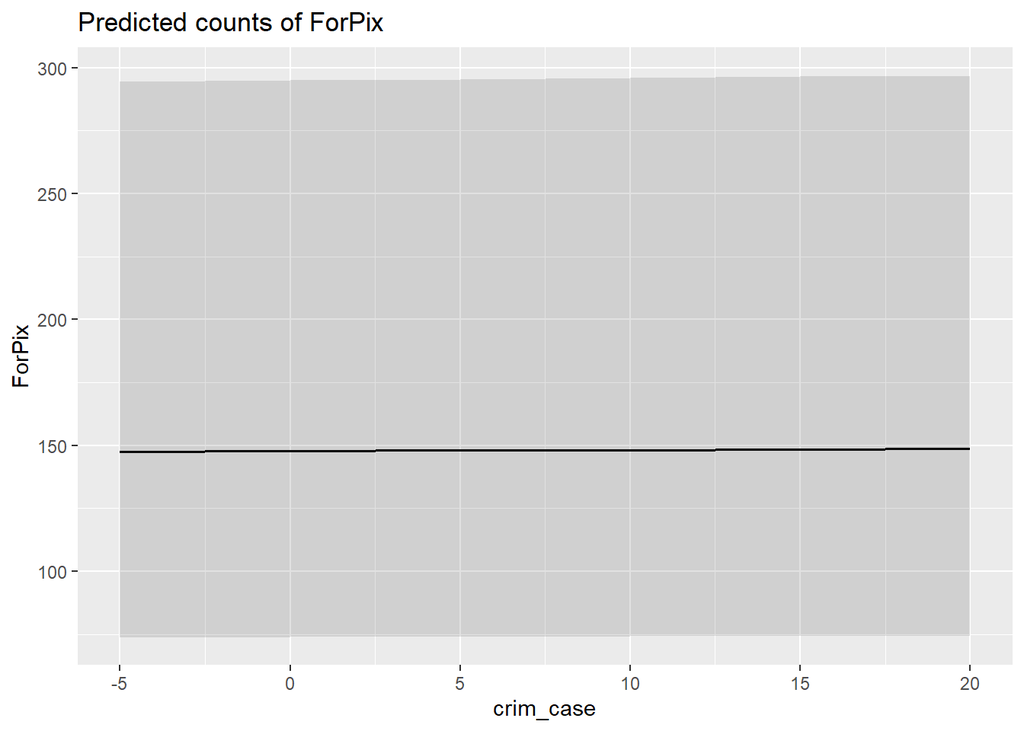

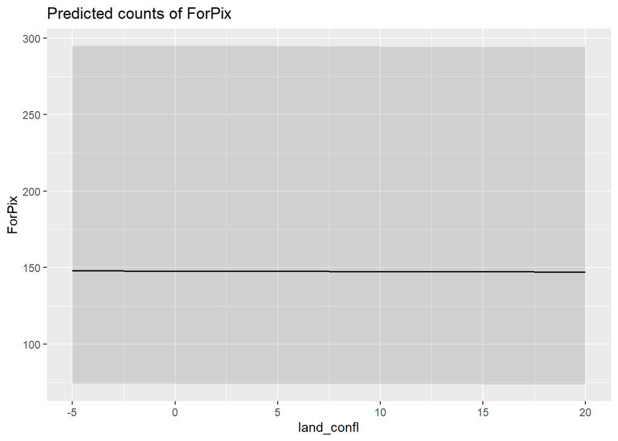

I removed land_confl for jus.m2, and LRT suggested the simpler model was better, but the resulting model still had tiny effect for crim_case, with large approximate p value. The plot was just as flat as jus.m1.

## Migration

There are two predictors in this set - raw number of in-migrants and out-migrants. For these variables, I thought there was cause to test an interaction, as the relationship between migration in and out of a commune is potentially complex, and intertwined with various aspects of the local economy and natural resource use.

```r
mig.m1 <- glmer(ForPix ~ Pax_migt_in*Pax_migt_out + offset(log(areaKM)) + (year|Province/Provcomm),
                family="poisson", data=dat1)
summary(mig.m1)
```

```
## Generalized linear mixed model fit by maximum likelihood (Laplace
##   Approximation) [glmerMod]
##  Family: poisson  ( log )
## Formula: ForPix ~ Pax_migt_in * Pax_migt_out + offset(log(areaKM)) + (year |
##     Province/Provcomm)
##    Data: dat1
##
##      AIC      BIC   logLik deviance df.resid
##  36587.6  36651.1 -18283.8  36567.6     4231
##
## Scaled residuals:
##     Min      1Q  Median      3Q     Max
## -6.1081 -0.0800 -0.0045  0.0285  9.7656
##
## Random effects:
##  Groups            Name        Variance  Std.Dev. Corr
##  Provcomm:Province (Intercept) 1.5760661 1.2554
##                    year        0.0045833 0.0677   0.20
##  Province          (Intercept) 1.8831301 1.3723
##                    year        0.0007726 0.0278   -0.30
## Number of obs: 4241, groups:  Provcomm:Province, 737; Province, 24
##
## Fixed effects:
##                            Estimate Std. Error z value Pr(>|z|)
## (Intercept)              -0.2472649  0.3587693  -0.689    0.491
## Pax_migt_in              -0.0004738  0.0008081  -0.586    0.558
## Pax_migt_out              0.0016831  0.0022545   0.747    0.455
## Pax_migt_in:Pax_migt_out  0.0005212  0.0007195   0.724    0.469
##
## Correlation of Fixed Effects:
##             (Intr) Px_mgt_n Px_mgt_t
## Pax_migt_in  0.008
## Pax_migt_ot  0.026 -0.061
## Px_mgt_:P__  0.001 -0.125   -0.433
## convergence code: 0
## Model is nearly unidentifiable: very large eigenvalue
##  - Rescale variables?
```

Very small effects and large approximate p values. No change in the RE variances

Quick plots of the marginal effects of interaction terms:

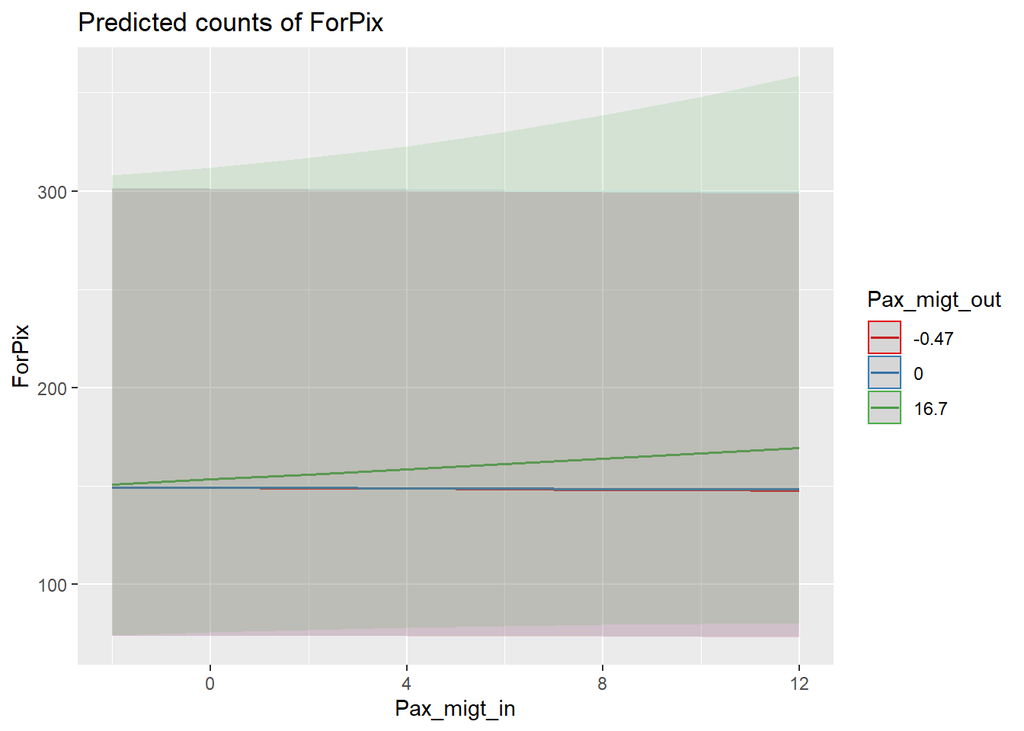

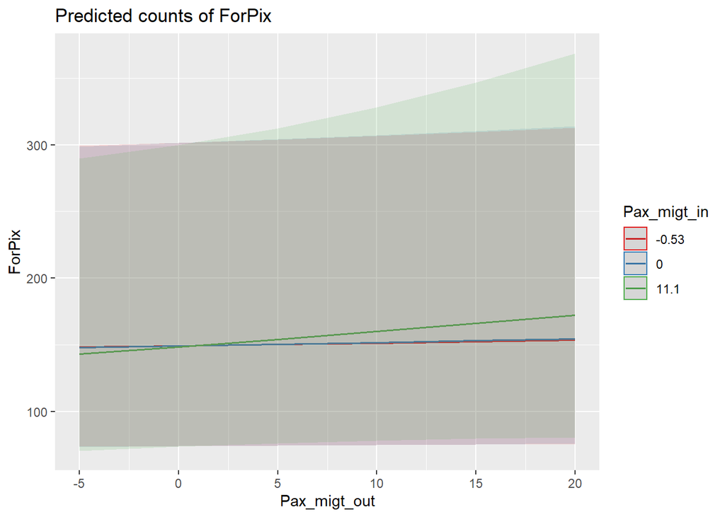

```r
mig.m2 <- glmer(ForPix ~ Pax_migt_out + offset(log(areaKM)) + (year|Province/Provcomm),
                family="poisson", data=dat1)

summary(mig.m2)
```

```
## Generalized linear mixed model fit by maximum likelihood (Laplace
##   Approximation) [glmerMod]
##  Family: poisson  ( log )
## Formula:
## ForPix ~ Pax_migt_out + offset(log(areaKM)) + (year | Province/Provcomm)
##    Data: dat1
##
##      AIC      BIC   logLik deviance df.resid
##  36584.4  36635.2 -18284.2  36568.4     4233
##
## Scaled residuals:
##     Min      1Q  Median      3Q     Max
## -6.1089 -0.0800 -0.0044  0.0289  9.7698
##
## Random effects:
##  Groups            Name        Variance  Std.Dev. Corr
##  Provcomm:Province (Intercept) 1.5761061 1.25543
##                    year        0.0045831 0.06770  0.20
##  Province          (Intercept) 1.8827169 1.37212
##                    year        0.0007744 0.02783  -0.30
## Number of obs: 4241, groups:  Provcomm:Province, 737; Province, 24
##
## Fixed effects:
##               Estimate Std. Error z value Pr(>|z|)
## (Intercept)  -0.245987   0.359234  -0.685    0.493
## Pax_migt_out  0.002260   0.002015   1.122    0.262
##
## Correlation of Fixed Effects:
##             (Intr)
## Pax_migt_ot 0.030
```

```r
anova(mig.m1,mig.m2,test="Chisq")
```

```
## Data: dat1
## Models:
## mig.m2: ForPix ~ Pax_migt_out + offset(log(areaKM)) + (year | Province/Provcomm)
## mig.m1: ForPix ~ Pax_migt_in * Pax_migt_out + offset(log(areaKM)) + (year |
## mig.m1:     Province/Provcomm)
##        npar   AIC   BIC logLik deviance  Chisq Df Pr(>Chisq)
## mig.m2    8 36584 36635 -18284    36568
## mig.m1   10 36588 36651 -18284    36568 0.7746  2     0.6789
```

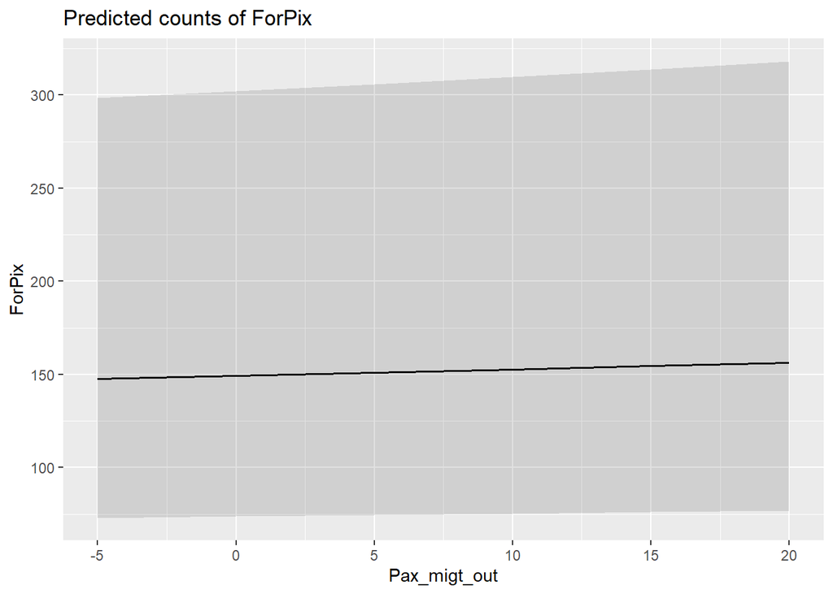

```r
# simpler model is better

plot_model(mig.m2, type="pred", terms="Pax_migt_out")
```